# CrossFit Open 24.1 Statistics Recap

Alejandro Reyes

The CrossFit Open is the largest participatory sport event on Earth, according to the official website, and it consists of three workouts spread over three weeks. The first workout of the CrossFit Open 2024 took place last weekend and participants in the Rx category had to perform the following exercises within maximum 15 minutes:

- 21 Dumbbell Snatches (arm 1) (50/35 lb)
- 21 Lateral Burpees Over Dumbbell
- 21 Dumbbell Snatches (arm 2) (50/35 lb)
- 21 Lateral Burpees Over Dumbbell
- 15 Dumbbell Snatches (arm 1) (50/35 lb)
- 15 Lateral Burpees Over Dumbbell
- 15 Dumbbell Snatches(arm 2) (50/35 lb)
- 15 Lateral Burpees Over Dumbbell
- 9 Dumbbell Snatches (arm 1) (50/35 lb)
- 9 Lateral Burpees Over Dumbbell
- 9 Dumbbell Snatches (arm 2) (50/35 lb)
- 9 Lateral Burpees Over Dumbbell

## Global distribution of 24.1 scores

An impressive 366589 participants submitted a score to the CrossFit Open website: 62% of participants competed in the “Rx” category, 33% competed in the “scaled” category and 5% competed in the “foundations” category.

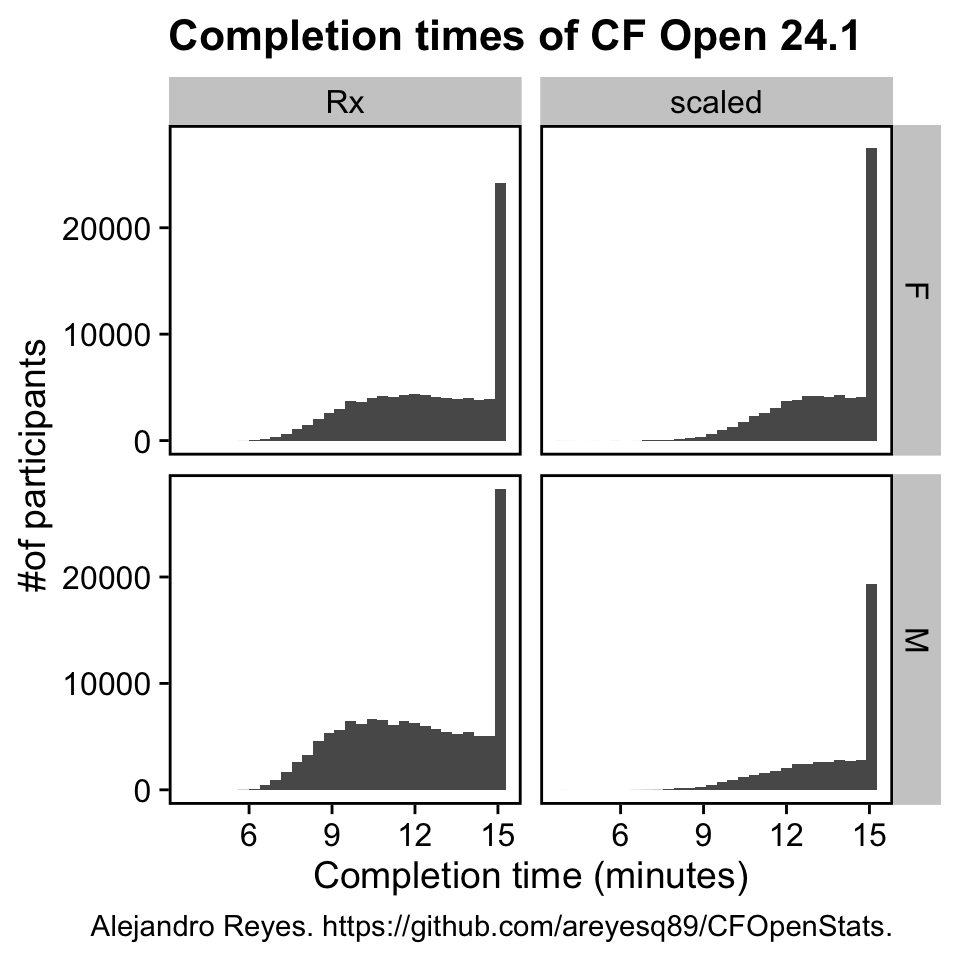

Figure 1: Distribution of completion times for 24.1.

Figure 1 shows the distribution of completion times for each category for male and female divisions. Across all categories, only  
15% of athletes completed the workout in less than 10 minutes and 28% could not complete all the repetitions within the 15 minute mark. It was a very though workout!

## How many seconds away are you from quarter-final scores?

Athletes that rank among the top 25% in the Rx category qualify to the quarterfinals. Table 1 shows how fast an athlete would have had to complete 24.1 in order to be within the top 25% in their age category.

Table 1: Completion time of the top 25% male athletes in 24.1

| division | Age group | 24.1 time |
| --- | --- | --- |
| M | 16-17 | 10M 23S |
| M | 18-34 | 9M 23S |
| M | 35-39 | 10M 12S |
| M | 40-44 | 10M 59S |
| M | 45-49 | 11M 45S |
| M | 50-54 | 12M 36S |

Table 2: Completion time of the top 25% female athletes in 24.1

| division | Age group | 24.1 time |
| --- | --- | --- |
| F | 16-17 | 10M 55S |
| F | 18-34 | 10M 14S |
| F | 35-39 | 10M 46S |
| F | 40-44 | 11M 20S |
| F | 45-49 | 11M 53S |
| F | 50-54 | 12M 36S |

For example, I am a 35-year-old male and I completed the Rx workout in 13:43, meaning that I’m more than two minutes away from being a quarter-final athlete!

## Comparing scores between CF boxes

Figure 2 shows a comparison of completion times between: - CF boxes with at least ten athletes in the CF Open leaderboard that had the best average scores worldwide (blue) - CF boxes in Basel, where I live and work out (red) - CF boxes in the rest of the world (green)

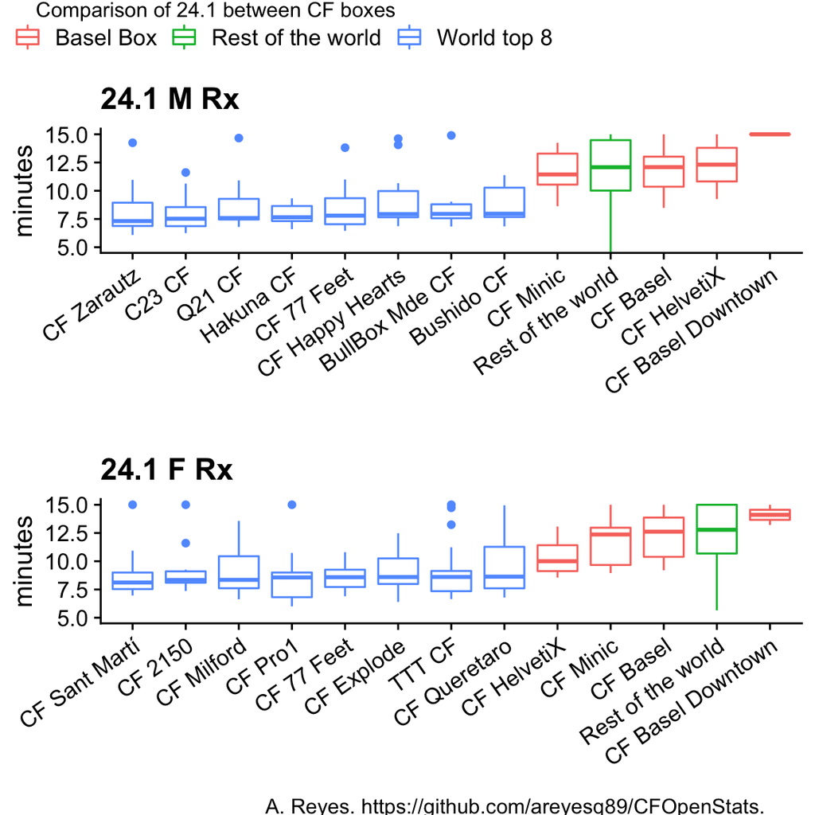

Figure 2: Distribution of completion times of top 8 world boxes and basel boxes.

It is interesting that in the Rx category, the completion times of male athletes from my CF box (CF HelvetiX) are very similar to those of CF boxes across the rest of the world. However, the completion times of female athletes from CF HelvetiX are much closer to the world’s top eight boxes.

## Conclusion

If you have to bet for someone in Basel to qualify to the CF Games quarter finals, bet on a CF HelvetiX female athlete!